# economic-analysis-of-a-stand-alone-solar-pv-system

Use the "Run" button to execute the code.

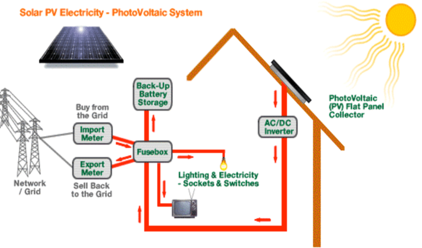

# Problem Statement

#### The Tax deduction are permissible only on depreciation, which is allowed at the rate of 25% each year, and the company income tax rate is 30%.

#### Assuming that the market discount rate is 10%, Calculate the net annual costs and the cumulative savings from year to year over a period of 8 years.

```python
!pip install jovian --upgrade --quiet
```

```python
import jovian
```

```python
# Execute this to save new versions of the notebook
jovian.commit(project="economic-analysis-of-a-stand-alone-solar-pv-system")
```

```
[jovian] Updating notebook "reachto-smitha/economic-analysis-of-a-stand-alone-solar-pv-system" on https://jovian.ai
[jovian] Committed successfully! https://jovian.ai/reachto-smitha/economic-analysis-of-a-stand-alone-solar-pv-system
```

```
'https://jovian.ai/reachto-smitha/economic-analysis-of-a-stand-alone-solar-pv-system'
```

the cost of an energy system is usually considered in two parts, an initial cost and an annual operating cost, As of now, these system have high initial costs and relatively low annual cost as compared to conventional system. The opposite is true for conventional system.

Generally The net annual cost of system maybe stated as follows

#### Net Annual cost of energy system = [Yearly costs]-[Yearly benefits]

#### = [Maintenance costs,Local taxes,manpower etc]+[Cost of fuel/electricity]+[Repayment of Loan]- [Tax deducted as available]

Cash flows are reduced to compute the equivalent present worth, which refers to discounting. The present worth of money required in some time in future is obtained by calculating how much would have to be invested at a rate called discount rate today, which can come handy in future. The present worth of rupees needed in n years from today is given by 1/(1+d)^n where d is the discount rate. The Sum of present worths is given by

#### S = FV/(1+d)^n Where FV is the final payment, sometimes it increase constantly by compounding.

For the present problem I am assuming that the payment is not compounding.

#### For the repayment of Loan in equal annual installments,

#### A = dl*fl*C/[1-{1/(1+d)^nl}]

where C = initial investment, fl is fraction of loan of the initial investment, dl= interest rate, A is equal annual installments to be maid over nl years.

Tax deduction depends on interest component of A

interest component= [1-((1+dl)^j-1)/(1+dl)^nl -1]*dl*fl*C But this is not required in the present system.

#### Tax Saving on depreciation = Cost of System * Company income tax rate/ (1/ tax rate at depreciation)

In the present problem the following information is given

```python
Loan_years = 5
depreciation_rate = 0.25
total_period = 8
Discount_rate = 0.1
Loan_rate= 0.05
If=0.05
Im=0.05
Income_tax_rate = 0.3
Cost_of_system = 250000
Fraction_Loan=0.8
Cost_of_fuel=4700
down_payment=50000
savings_due_use_of_Pv_system=47000
```

```python
Loan=Fraction_Loan*Cost_of_system
print("Loan amount is {}".format(Loan))
```

```
Loan amount is 200000.0
```

```python
# for the First Year, The Annual replayment of Loan can be calculated as follows
Loan_years_converted=int(Loan_years)
Annual_repayment=Loan_rate*Loan/(1-(1/(1+Loan_rate)**Loan_years_converted))
print("Annual repayment of Loan in equal amounts is {}".format(Annual_repayment))
```

```
Annual repayment of Loan in equal amounts is 46194.959625653595
```

```python
Tax_saving_depreciation= Cost_of_system*Income_tax_rate/(1/depreciation_rate)
print("Saving of Tax on depreciation is {}".format(Tax_saving_depreciation))
```

```
Saving of Tax on depreciation is 18750.0
```

```python
Cost_of_maintenance = 9000
Net_annual_cost = Cost_of_fuel + Cost_of_maintenance+ Annual_repayment - (Tax_saving_depreciation+Cost_of_fuel)
print(" The net annual cost of operation is {}".format(Net_annual_cost))
```

```
 The net annual cost of operation is 36444.959625653595
```

```python
Present_net_worth_cost=5323
Cumulative_saving_year_1 = - down_payment + Present_net_worth_cost
print("The cumulative saving for 1st year is {}".format(Cumulative_saving_year_1))
```

```
The cumulative saving for 1st year is -44677
```

```python
cost_of_aux_and_fuel=[]
for i in range(9):
    Cost_of_fuel=4700
    Cost_of_fuel+=240*i
    cost_of_aux_and_fuel.append(Cost_of_fuel)
cost_of_aux_and_fuel.insert(0,0)
print(cost_of_aux_and_fuel)
```

```
[0, 4700, 4940, 5180, 5420, 5660, 5900, 6140, 6380, 6620]
```

### Lets FInd out cost of maintenance assuming that maintenance cost will increase by 450 each year

```python
maintenance_cost=[]
for i in range(9):
    Cost_of_maintenance=9000
    Cost_of_maintenance+=450*i
    maintenance_cost.append(Cost_of_maintenance)
maintenance_cost.insert(0,0)
print(maintenance_cost)
```

```
[0, 9000, 9450, 9900, 10350, 10800, 11250, 11700, 12150, 12600]
```

## Lets find out the Tax savings due to depreciation

```python
Tax_saving_on_depreciation=[]
for i in range(9):
    if(i<=4):
        Tax_saving_depreciation=18750.0
        Tax_saving_on_depreciation.append(Tax_saving_depreciation)
    else:
        Tax_saving_on_depreciation.append(0)
Tax_saving_on_depreciation.insert(0,0)
print(Tax_saving_on_depreciation)
```

```
[0, 18750.0, 18750.0, 18750.0, 18750.0, 18750.0, 0, 0, 0, 0]
```

## Lets find out the Loan that has to be paid.

```python
loan_amount_to_repay=[]
for i in range(9):
    if(i<=5):
        Annual_repayment=46194.959625653595
        loan_amount_to_repay.append(Annual_repayment)
    else:
        loan_amount_to_repay.append(0)
loan_amount_to_repay.insert(0,0)
print(loan_amount_to_repay)
```

```
[0, 46194.959625653595, 46194.959625653595, 46194.959625653595, 46194.959625653595, 46194.959625653595, 46194.959625653595, 0, 0, 0]
```

## Lets find out the savings due to non conventional energy system

```python
savings=[]
for i in range(9):
    savings_due_use_of_Pv_system=47000
    savings_due_use_of_Pv_system+=2400*i
    savings.append(savings_due_use_of_Pv_system)
savings.insert(0,0)
print(savings)
```

```
[0, 47000, 49400, 51800, 54200, 56600, 59000, 61400, 63800, 66200]
```

# Lets construct a table using pandas

```python
import pandas as pd
```

```python
Calculations={
    'year':[0,1,2,3,4,5,6,7,8,9],
    'Initial Down Payment':[down_payment,'NAN','NAN','NAN','NAN','NAN','NAN','NAN','NAN','NAN'],
    'Cost of fuel used in auxiliary system': cost_of_aux_and_fuel,
    'Maintenance Cost':maintenance_cost,
    'Repayment of Loan':loan_amount_to_repay,
    'Tax saving on Depreciation':Tax_saving_on_depreciation,
    'Savings due to use of PV system':savings
}
Savings_df=pd.DataFrame(Calculations)
```

```python
Savings_df
```

|  | year | Initial Down Payment | Cost of fuel used in auxiliary system | Maintenance Cost | Repayment of Loan | Tax saving on Depreciation | Savings due to use of PV system |
| --- | --- | --- | --- | --- | --- | --- | --- |
| 0 | 0 | 50000 | 0 | 0 | 0.000000 | 0.0 | 0 |
| 1 | 1 | NAN | 4700 | 9000 | 46194.959626 | 18750.0 | 47000 |
| 2 | 2 | NAN | 4940 | 9450 | 46194.959626 | 18750.0 | 49400 |
| 3 | 3 | NAN | 5180 | 9900 | 46194.959626 | 18750.0 | 51800 |
| 4 | 4 | NAN | 5420 | 10350 | 46194.959626 | 18750.0 | 54200 |
| 5 | 5 | NAN | 5660 | 10800 | 46194.959626 | 18750.0 | 56600 |
| 6 | 6 | NAN | 5900 | 11250 | 46194.959626 | 0.0 | 59000 |
| 7 | 7 | NAN | 6140 | 11700 | 0.000000 | 0.0 | 61400 |
| 8 | 8 | NAN | 6380 | 12150 | 0.000000 | 0.0 | 63800 |
| 9 | 9 | NAN | 6620 | 12600 | 0.000000 | 0.0 | 66200 |